# BL40A2010 Introduction to IoT-Based Systems

## Assignment 1, 18.01.2023

### Author: Semen Koveshnikov

**(1) Analyze an electric heater as a system following Example 1.1.**

Answer:

- **Peculiar operation** - conversion of electrical energy to heat via heating elements.
- **Conditions of production** - heat emission may be obtained in different ways with various heating element structure and material. Elements are heated thanks to high resistance of material.
- **Conditions of reproduction** - connection to electrical network (hence, its existence as well) with required voltage level, maintenance.
- **External conditions** - cold/cool weather, affordable electricity.

**(2) Give one example for each scientific rationalities presented in Section 1.2.1 similar to Example 1.2.**

Answer:

Renewable energy sources (RES) reliability. 2050 carbon neutrality goals include transition to renewable energy with penetration up to 100%. This poses multitude of challenges to grids, as solar and wind farms are intermittent generators. Moreover, they are converter-connected, thus, not aiding grid stability.

- **Classical** - High penetration rate of RES in networks leads to degraded network planning, risks reliability and stability of the grid. Power quality is not under control as required.
- **Non-classical** - Germany is managing its high number of solar panels and wind farms well, utilizing import/export transmission links and market signals.
- **Interventionist** - Grid-formind converters, energy storages and power-to-X technologies will relieve the consequences of wide renewable generation integration. When these assets become available in mass production, the issues will be solved.

*Hint:* Code like in the tutorial notebook.

```python
#libs import
import pandas as pd
import numpy as np
import matplotlib.pyplot as plt
import matplotlib.dates as mdates
```

```python
#data imported from csv
weather_Helsinki = pd.read_csv("weather.csv",dayfirst=True,sep=",",
                          header=0,decimal=b".",index_col=0,
                          parse_dates= [[0, 1, 2, 3]],usecols=[0,1,2,3,5])
weather_Helsinki.info()
weather_Helsinki.head()
```

```
<class 'pandas.core.frame.DataFrame'>
DatetimeIndex: 8809 entries, 2020-01-01 00:00:00 to 2021-01-02 00:00:00
Data columns (total 1 columns):
 #   Column                  Non-Null Count  Dtype
---  ------                  --------------  -----
 0   Air temperature (degC)  8809 non-null   object
dtypes: object(1)
memory usage: 137.6+ KB
```

| Year_m_d_Time | Air temperature (degC) |
| --- | --- |
| 2020-01-01 00:00:00 | -0.2 |
| 2020-01-01 01:00:00 | 0.2 |
| 2020-01-01 02:00:00 | 0.4 |
| 2020-01-01 03:00:00 | 0.7 |
| 2020-01-01 04:00:00 | 0.8 |

```python
#data cleaning
weather_Helsinki['Air temperature (degC)']=weather_Helsinki['Air temperature (degC)'].map(lambda x: np.NAN if x=='-'else x)
weather_Helsinki.loc[weather_Helsinki['Air temperature (degC)']=='-']
weather_Helsinki['Air temperature (degC)'] =weather_Helsinki['Air temperature (degC)'].astype('float')
weather_Helsinki['Air temperature (degC)']=weather_Helsinki['Air temperature (degC)'].fillna(method='ffill')
```

```
Text(2020-01-01 00:00:00, 9.646770348507209, 'Mean temperature 8.65 °C')
```

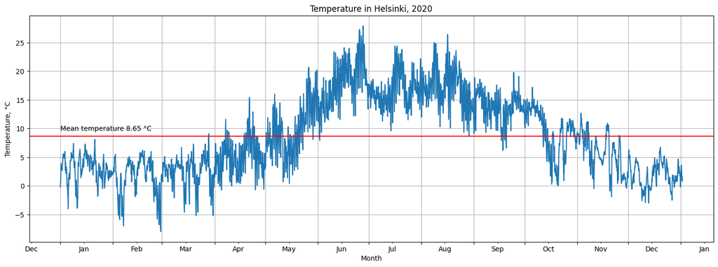

```python
#plotting year 2020
fig, ax=plt.subplots(figsize=(18,6))
plt.plot(weather_Helsinki)
ax.set(title='Temperature in Helsinki, 2020',ylabel='Temperature, °C',
xlabel='Month')
plt.grid(True)
mean_year=weather_Helsinki['Air temperature (degC)'].mean()
plt.axhline(y=mean_year,color='red')
ax.xaxis.set_major_locator(mdates.MonthLocator())
ax.xaxis.set_minor_locator(mdates.MonthLocator(bymonthday=15))
ax.xaxis.set_major_formatter(plt.NullFormatter())
ax.xaxis.set_minor_formatter(mdates.DateFormatter('%h'))
ax.text(pd.to_datetime('2020-01'),mean_year+1,"Mean temperature {0} °C".format(round(mean_year,2)))
```

```
Text(2020-07-07 00:00:00, 19.683736559139785, 'Mean temperature 16.68 °C')
```

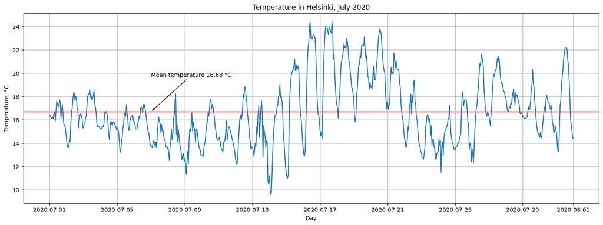

```python
#plotting month July 2020
fig, ax=plt.subplots(figsize=(18,6))
plt.plot(weather_Helsinki.loc['2020-07'])
ax.set(title='Temperature in Helsinki, July 2020',ylabel='Temperature, °C',
xlabel='Day')
plt.grid(True)
mean_month=weather_Helsinki['Air temperature (degC)']['2020-07'].mean()
plt.axhline(y=mean_month,color='red')
ax.annotate("Mean temperature {0} °C".format(round(mean_month,2)), xy=(pd.to_datetime('2020-07-07'),mean_month),
xytext=(pd.to_datetime('2020-07-07'),mean_month+3),arrowprops=dict(arrowstyle='->',facecolor='black'))
```

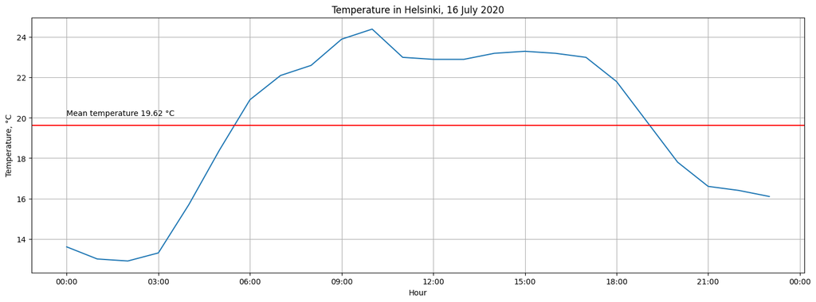

```python
#plotting month day July 16 2020
fig, ax=plt.subplots(figsize=(18,6))
plt.plot(weather_Helsinki.loc['2020-07-16'])
ax.set(title='Temperature in Helsinki, 16 July 2020',ylabel='Temperature, °C',
xlabel='Hour')
plt.grid(True)
mean_day=weather_Helsinki['Air temperature (degC)']['2020-07-16'].mean()
plt.axhline(y=mean_day,color='red')
ax.text(pd.to_datetime('2020-07-16 00:00:00'),mean_day+0.5,"Mean temperature {0} °C".format(round(mean_day,2)))
ax.xaxis.set_major_formatter(mdates.DateFormatter('%H:%M'))
```

**(4) Consider a house with an electric heater. How the electricity consumption of the heater would be affected by the outside air temperature? Discuss about 3 current heating methods and their differences.**

Answer:

Naturally, when outside temperature lowers, heater is working for a longer period to heat the house to the set temperature. Hence, electricity consumption increases and the maximum figure will be reached when heater is always on with maximum output power. In other words, outside temperature and electricity consumption are roughly inversly proportional.

In Finland, a popular type for heating is heat pump. The working principle relies on temperature difference of heat exchangers. A refrigerant is circulating in a closed loop and dissipate or absorbs heat at required side. Thus, it also works in cooling mode. The electricity is consumed by ventilators, compressor and controlling electrocnics, so it can be considered as a energy saving heating compared to other heater types.

There are electric resistance heaters used in domestic households, too. They are efficient heaters, as 100% of electricity is converted to heat in resistive elements. However, the consumption is also high, which makes these heaters only suitable for small-scale use.

A more sophisticated type of heating is hydronic radiant floors. Heating cable tubes are installed in the floor, where a hot water is circulating. Water can be boiled in a common house boiler or a separate one. The floor concrete or other material acts as a thermal mass. This heating type is quite efficient thanks to controlling scheme and big thermal mass. On the other hand, it is only implementable in a detached houses. Yet, in block of flats similar structure can be used, but with reistive heating floor cables. They outperform conventional radiators due to the thermal mass.

By and large, up-to-date heating means are in parity, and choice can be made with consideration of physical, technical and capital expenses constraints.